# Will the Model Work on New Data?

Lesson 30 — Train-Test Split, Overfitting, and Adjusted R-Squared

Lt Col Cho

# Where We Left Off

$R^2$ never decreases when a predictor is added

More complex models · Adjusted R-squared · Train-test split · Overfitting · Comparing the tools

## Two questions

**Question 1**

If we keep adding explanatory variables, what happens to $R^2$? Does a higher $R^2$ mean a better model?

**Question 2**

If a regression model fits its sample data very closely, does it necessarily predict **new** observations accurately?

Today: compare models of increasing complexity, first on the data used to fit them, then on observations **not** used to fit them

# More Complex Models

Adding powers of $x$ to the model

## A random sample of 100 cadets

- Our data: a random sample of **100** cadets.
- Before any model is fit, **70** of the 100 cadets are selected at random. Every model in the next two sections is fit to these 70 cadets.
- The other **30** cadets are set aside and not used until the train-test section.

```r
set.seed(162)
cadet_sample <- slice_sample(cadets, n = 100)
training <- slice_sample(cadet_sample, n = 70)
```

Study hours among the 70 cadets range from 9 to 27.7.

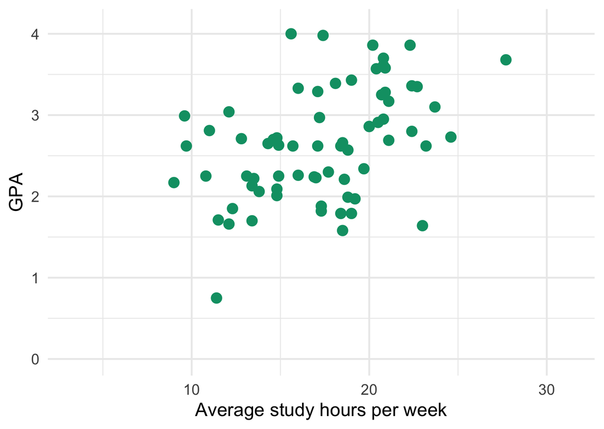

## Polynomial models are still linear regression

**Degree 1** (a line):

$$\hat{y} = b_0 + b_1 x$$

**Degree 2:**

$$\hat{y} = b_0 + b_1 x + b_2 x^2$$

**Degree $d$:**

$$\hat{y} = b_0 + b_1 x + b_2 x^2 + \cdots + b_d x^d$$

- “Linear” regression means **linear in the coefficients** $b_j$; the predictors $x, x^2, \ldots$ are columns in the data.
- A degree-$d$ model has $k = d$ predictors.

```r
mod_1 <- lm(gpa ~ avg_study_hours,
            data = training)

mod_2 <- lm(gpa ~ avg_study_hours +
              I(avg_study_hours^2),
            data = training)

# poly(x, 8) includes x, x^2, ..., x^8
mod_8 <- lm(gpa ~ poly(avg_study_hours, 8),
            data = training)

summary(mod_8)$r.squared
```

## Fits to the 70 cadets

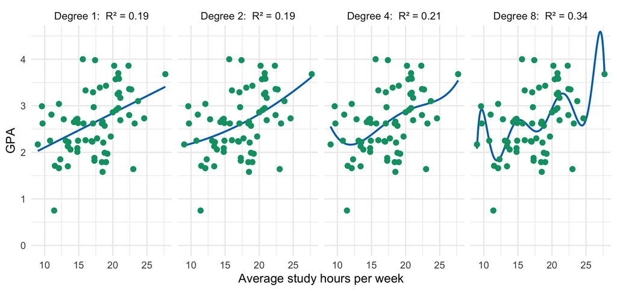

Each added power lets the curve pass **closer** to the 70 points used to fit it

## $R^2$ never decreases as terms are added

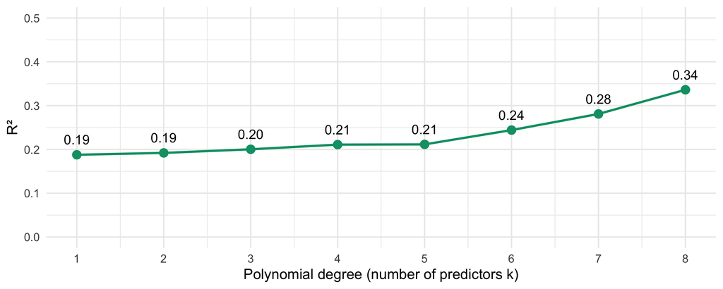

By $R^2$ alone, the degree-8 model explains the most variation

# Adjusted $R^2$

A penalty for each predictor in the model

## $R^2$ rises even for predictors that are pure noise

The same 70 cadets. Predict GPA from study hours, then add **random numbers** (`rnorm()`) as extra predictors.

```r
lm(gpa ~ avg_study_hours + noise1 +
     noise2 + noise3, data = training)
```

The noise columns are generated independently of GPA.

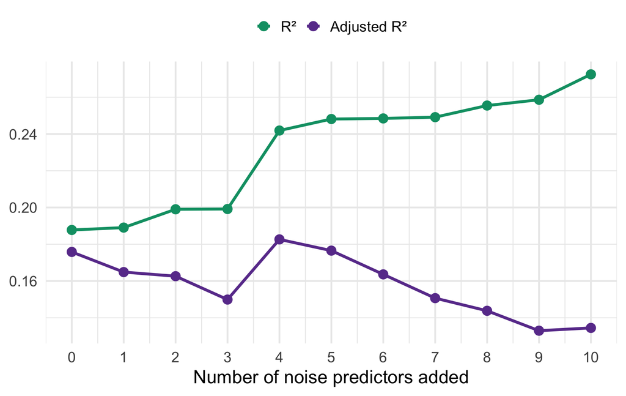

$R^2$ never decreased as noise predictors were added (0.19 → 0.27); adjusted $R^2$ fell (0.18 → 0.13)

## Adjusted $R^2$

$$R^2_{adj} = 1 - \frac{s^2_{\text{residuals}}}{s^2_{\text{outcome}}} \times \frac{n - 1}{n - k - 1}
\qquad\qquad
R^2 = 1 - \frac{s^2_{\text{residuals}}}{s^2_{\text{outcome}}}$$

**Notation**

- $n$ = number of observations used to fit the model
- $k$ = number of predictors (a categorical predictor with $p$ levels counts as $p - 1$)

**Properties**

- Each added predictor increases $\dfrac{n-1}{n-k-1}$, so a predictor must reduce the residual variance enough to offset it
- $R^2_{adj} \le R^2$; it **can decrease**, and it can be negative
- With $k = 1$ and large $n$, $R^2_{adj} \approx R^2$

| Comparing models with… | Use |
| --- | --- |
| one predictor, or the **same** number of predictors | $R^2$ |
| **different** numbers of predictors | adjusted $R^2$ |

## Adjusted $R^2$ for the polynomial models

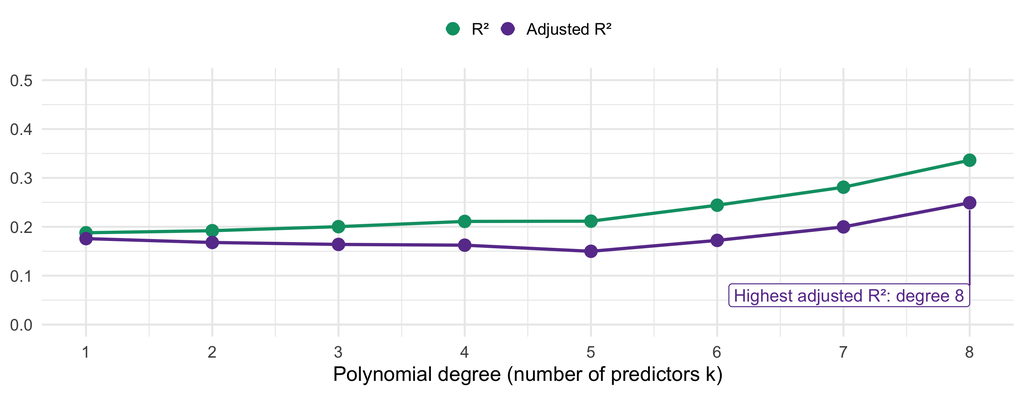

Adjusted $R^2$ for degrees 2–6 is no higher than for degree 1; its maximum is at **degree 8**. Both measures are computed from the 70 cadets used to fit the models.

# Train-Test Split

Evaluate the models on observations not used to fit them

## Training data and test data

**Training data:** the observations used to fit the model (estimate $b_0, b_1, \ldots$)

**Test data:** observations held out during model building and used only to evaluate predictions

```r
set.seed(162)
cadet_sample <- slice_sample(cadets, n = 100)
training <- slice_sample(cadet_sample, n = 70)
test     <- anti_join(cadet_sample, training,
                      by = "cadet_id")
```

A random **70% / 30%** split of the sample of 100:

- Training: the **70** cadets used to fit every model so far
- Test: the other **30** cadets, not used to fit any model

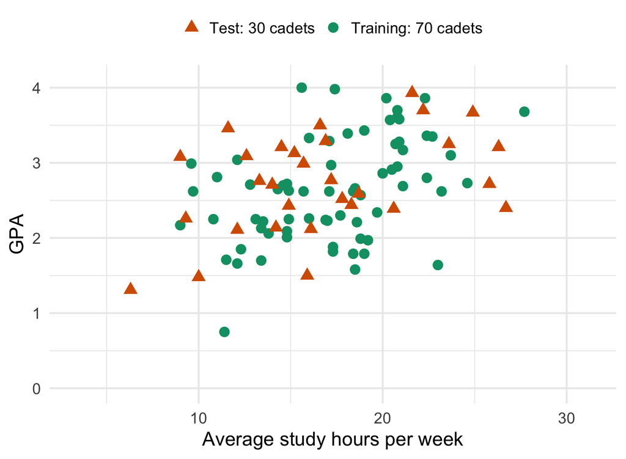

## Why hold data out?

- **$R^2$ and adjusted $R^2$ are computed from the training data.** Least squares chooses the coefficients that minimize the training residuals, so both measures describe the model on the data it was fit to.
- **The goal is prediction for new observations** from the same population.
- If **all** observations are used to fit the model, no observations remain for an independent evaluation.
- **Typical split:** 70% / 30% or 80% / 20%, chosen at random.
- **The test set is used once.** Selecting a model *because* it performs best on the test set makes the test set part of model selection, and its error is no longer an independent estimate.

Fit on **training** data · evaluate on **test** data

## Degree 1 vs. degree 8 on the test cadets

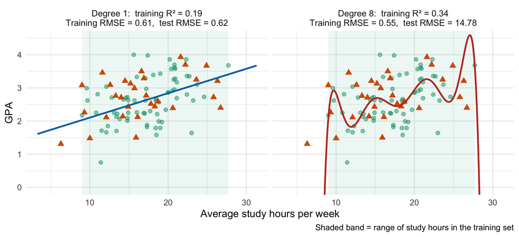

$$\text{RMSE} = \sqrt{\frac{1}{n}\sum_{i=1}^{n} (y_i - \hat{y}_i)^2}
\quad = \text{typical size of a prediction error, in GPA points}$$

## Training error vs. test error

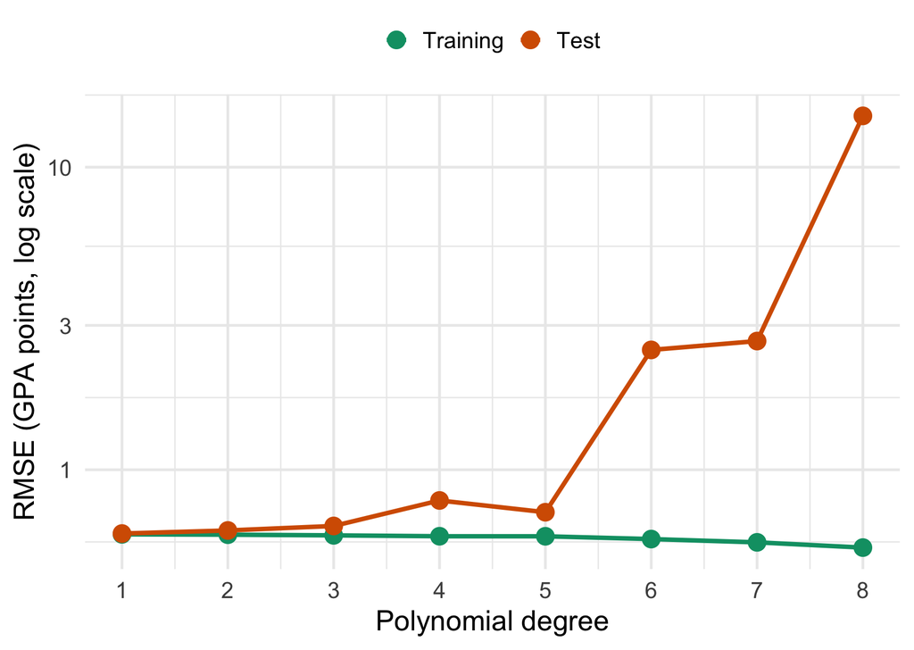

| Degree | R² | Adj. R² | Train RMSE | Test RMSE |
| --- | --- | --- | --- | --- |
| 1 | 0.19 | 0.18 | 0.61 | 0.62 |
| 2 | 0.19 | 0.17 | 0.61 | 0.63 |
| 3 | 0.20 | 0.16 | 0.61 | 0.65 |
| 4 | 0.21 | 0.16 | 0.60 | 0.79 |
| 5 | 0.21 | 0.15 | 0.60 | 0.72 |
| 6 | 0.24 | 0.17 | 0.59 | 2.49 |
| 7 | 0.28 | 0.20 | 0.58 | 2.66 |
| 8 | 0.34 | 0.25 | 0.55 | 14.78 |

Training error decreases with degree; **test error is smallest for degree 1**

# Overfitting

Close fit to the training data, poor predictions for new data

## Overfitting and underfitting

**Overfitting**

The model performs well on the training data but substantially worse on new data, because it has fit random variation specific to the training sample.

**High variance:** the fitted model changes substantially from one training sample to another.

**Underfitting**

The model is too simple to represent the relationship, so it performs poorly on **both** training and new data.

**High bias:** the model’s predictions differ systematically from the true values.

Increasing complexity decreases bias and increases variance. Select the **simplest** model that predicts new data well (**parsimony**).

## Variance: five different training sets

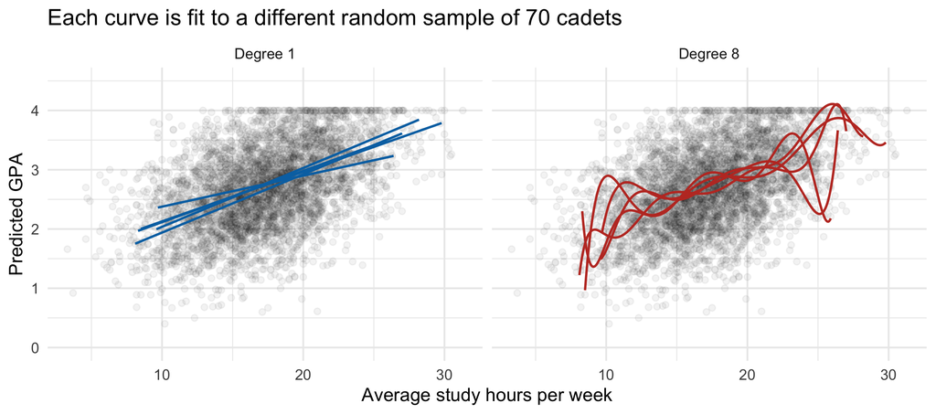

The degree-1 fits vary little across samples; the degree-8 fits vary substantially

## Overfitting depends on the size of the training set

Suppose the data were all 4,035 cadets instead of a sample of 100. An 80% / 20% split gives **3,228 training**, **807 test**.

| Degree | Training R² | Adjusted R² | Test RMSE |
| --- | --- | --- | --- |
| 1 | 0.2115 | 0.2113 | 0.585 |
| 2 | 0.2116 | 0.2111 | 0.584 |
| 3 | 0.2120 | 0.2112 | 0.584 |
| 8 | 0.2126 | 0.2107 | 0.583 |

With 3,228 training cadets, test RMSE changes by less than 0.01 GPA points from degree 1 to degree 8

# Comparing the Tools

Strengths and limitations of each measure of model performance

## Three ways to assess a model

| Measure | What it measures | Strength | Limitation |
| --- | --- | --- | --- |
| $R^2$ | Proportion of the variation in the **training** $y$ explained by the model | Directly interpretable; appropriate for one predictor or models with the same number of predictors | Never decreases when a predictor is added; overstates performance on new data |
| Adjusted $R^2$ | $R^2$ with a penalty for each predictor, using $n - k - 1$ | Can decrease when an added predictor does not reduce residual variance enough; requires no extra data | Still computed from the training data; selected the degree-8 model here |
| Test RMSE | Typical prediction error for observations **not** used to fit the model | Directly estimates performance on new data | Uses data that could have been used for fitting; depends on the random split; loses independence if used repeatedly to select models |

For our 70 training and 30 test cadets: $R^2$ → degree 8 · adjusted $R^2$ → degree 8 · test RMSE → **degree 1**